# Project Proposal

Liza, Kemunto, and Patrick

October 21, 2021

```r
library(tidyverse)
library(broom)
library(streamgraph) # to install stream graph run the below
#devtools::install_github("hrbrmstr/streamgraph")
library(ggstream)
library(ggplot2)
library(RColorBrewer)
```

## 1. Introduction

These criteria are whether the ad contains humor, shows the product quickly, is patriotic, contains a celebrity, contains danger, contains animals, and/or uses sexuality. The other variables in this data set include the year the ad was made, the brand for the commercial, Youtube view count, Youtube like count, Youtube dislike count, and Youtube comment count.

The specific questions we want to answer using this data set are:

- How does the popularity of different kinds of ads change over time? Are there events that help to contextualize this?
- What is the breakdown of ad categories across brands?
- Are Superbowl ads becoming more popular on Youtube over the years? Are new Superbowl ads getting more views?
- Are there more comments on ads that are more or less popular? Does more dislikes translate to more comments? More likes? Are there categories of ads or specific brands that we can identify a positive or negative relationship between the number of dislikes and the number of comments or the number of likes and the number of comments?
- Are ads published on official brand Youtube channels more popular than those posted on personal channels or channels that compile funny ads?

## 2. Data

We did not add our data to the /data folder since we loaded our data through the following link:

```r
youtube <- readr::read_csv('https://raw.githubusercontent.com/rfordatascience/tidytuesday/master/data/2021/2021-03-02/youtube.csv')
```

Taking a look at the data:

```r
glimpse(youtube)
```

```
## Rows: 247
## Columns: 25
## $ year                      <dbl> 2018, 2020, 2006, 2018, 2003, 2020, 2020, 20…
## $ brand                     <chr> "Toyota", "Bud Light", "Bud Light", "Hynudai…
## $ superbowl_ads_dot_com_url <chr> "https://superbowl-ads.com/good-odds-toyota/…
## $ youtube_url               <chr> "https://www.youtube.com/watch?v=zeBZvwYQ-hA…
## $ funny                     <lgl> FALSE, TRUE, TRUE, FALSE, TRUE, TRUE, TRUE, …
## $ show_product_quickly      <lgl> FALSE, TRUE, FALSE, TRUE, TRUE, TRUE, FALSE,…
## $ patriotic                 <lgl> FALSE, FALSE, FALSE, FALSE, FALSE, FALSE, FA…
## $ celebrity                 <lgl> FALSE, TRUE, FALSE, FALSE, FALSE, TRUE, TRUE…
## $ danger                    <lgl> FALSE, TRUE, TRUE, FALSE, TRUE, TRUE, FALSE,…
## $ animals                   <lgl> FALSE, FALSE, TRUE, FALSE, TRUE, TRUE, TRUE,…
## $ use_sex                   <lgl> FALSE, FALSE, FALSE, FALSE, TRUE, FALSE, FAL…
## $ id                        <chr> "zeBZvwYQ-hA", "nbbp0VW7z8w", "yk0MQD5YgV8",…
## $ kind                      <chr> "youtube#video", "youtube#video", "youtube#v…
## $ etag                      <chr> "rn-ggKNly38Cl0C3CNjNnUH9xUw", "1roDoK-SYqSp…
## $ view_count                <dbl> 173929, 47752, 142310, 198, 13741, 23636, 30…
## $ like_count                <dbl> 1233, 485, 129, 2, 20, 115, 1470, 78, 342, 7…
## $ dislike_count             <dbl> 38, 14, 15, 0, 3, 11, 384, 6, 7, 0, 14, 0, 2…
## $ favorite_count            <dbl> 0, 0, 0, 0, 0, 0, 0, 0, 0, 0, 0, 0, 0, 0, 0,…
## $ comment_count             <dbl> NA, 14, 9, 0, 2, 13, 227, 6, 30, 0, 8, 1, 13…
## $ published_at              <dttm> 2018-02-03 11:29:14, 2020-01-31 21:04:13, 2…
## $ title                     <chr> "Toyota Super Bowl Commercial 2018 Good Odds…
## $ description               <chr> "Toyota Super Bowl Commercial 2018 Good Odds…
## $ thumbnail                 <chr> "https://i.ytimg.com/vi/zeBZvwYQ-hA/sddefaul…
## $ channel_title             <chr> "Funny Commercials", "VCU Brandcenter", "Joh…
## $ category_id               <dbl> 1, 27, 17, 22, 24, 1, 24, 2, 24, 24, 24, 24,…
```

## 3. Data analysis plan

To answer our overarching question about ad popularity over time, the response variable will be popularity and the explanatory variable will be year. We will create a new variable called popularity, the proportion of likes per total views on a given ad. We will explore the popularity of Superbowl ads that fall into each of the seven specified categories as well as the popularity of ads aired by each of the 10 brands. The following is a figure of the number of views on ads in the last 21 Superbowls:

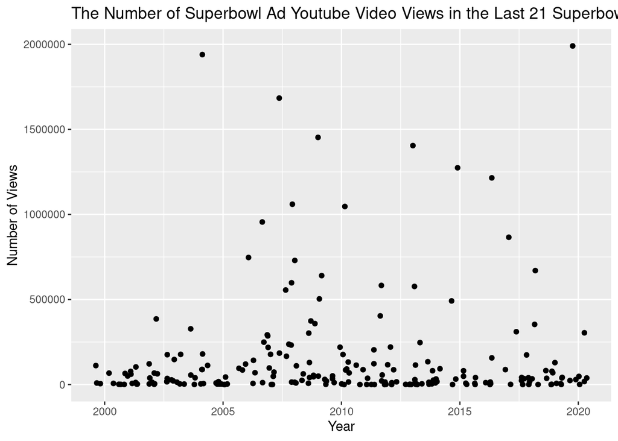

```r
youtube %>%
  filter(view_count < 2000000) %>%
  ggplot(aes(x = year, y = view_count)) +
  geom_jitter() +
  labs(x = "Year",
       y = "Number of Views",
       title = "The Number of Superbowl Ad Youtube Video Views in the Last 21 Superbowls")
```

From this figure, we see that most ads get less than 500,000 views, while outlier ads get up to 2,000,000 views. There is no clear relationship between year and number of views, but we are hoping to show that ad category and brand affect the number of views across Superbowl years.

Next, we can visualize the trend in the number of likes on these ads. The figure below shows the number of likes on ads in the last 21 Superbowls:

[figure not shown]

```r
youtube %>%
  filter(like_count < 10000) %>%
  ggplot(aes(x = year, y = like_count)) +
  geom_jitter() +
  labs(x = "Year",
       y = "Number of Likes",
       title = "The Number of Superbowl Ad Youtube Video Likes in the Last 21 Superbowls")
```

To analyze ad popularity by brand, we will create a figure of ad popularity over time, faceted by the 10 brands in our data set. The following is a figure of the number of views on ads in the last 21 Superbowls by brand:

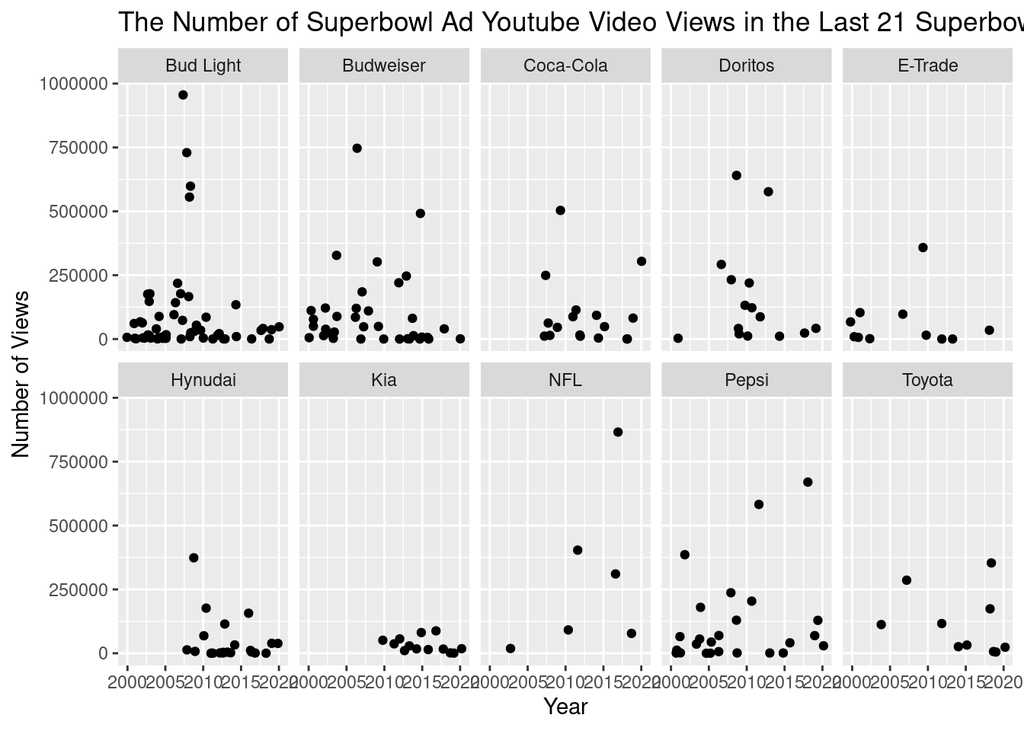

```r
youtube %>%
  filter(view_count < 1000000) %>%
  ggplot(aes(x = year, y = view_count)) +
  geom_jitter() +
  facet_wrap(~ brand, ncol = 5) +
  labs(x = "Year",
       y = "Number of Views",
       title = "The Number of Superbowl Ad Youtube Video Views in the Last 21 Superbowls")
```

From this figure, we can see that brands like Bud Light, Budweiser and NFL get more views on their ads. This may be because these ads are associated with the Superbowl.

Next, we can visualize the trend in the number of likes on these ads by brand. The figure below shows the number of likes on ads in the last 21 Superbowls:

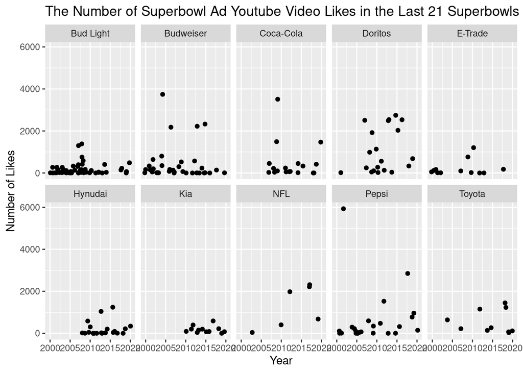

```r
youtube %>%
  filter(like_count < 10000) %>%
  ggplot(aes(x = year, y = like_count)) +
  geom_jitter() +
  facet_wrap(~ brand, ncol = 5) +
  labs(x = "Year",
       y = "Number of Likes",
       title = "The Number of Superbowl Ad Youtube Video Likes in the Last 21 Superbowls")
```

Then, we can analyze the popularity of these ads. The following figure shows the popularity of ads in the last 21 Superbowls by brand:

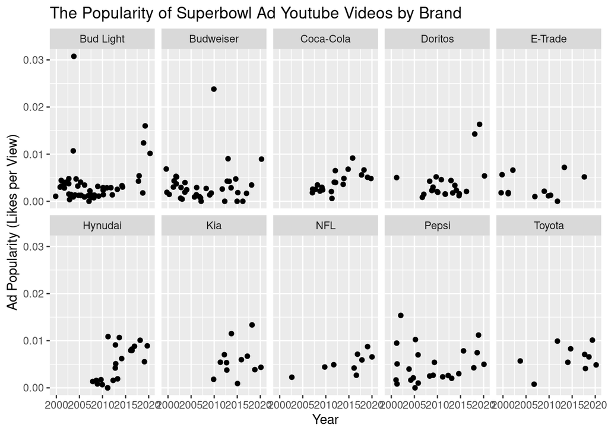

```r
youtube %>%
  mutate(likes_per_view = youtube$like_count/youtube$view_count) %>%
  ggplot(aes(x = year, y = likes_per_view)) +
  geom_jitter() +
  facet_wrap(~brand, ncol = 5) +
  labs(x = "Year",
       y = "Ad Popularity (Likes per View)",
       title = "The Popularity of Superbowl Ad Youtube Videos by Brand")
```

From this figure, we can see that most brands receive less than 0.02 likes per view, with a few ads from Budlight and Budweiser getting more likes per view. We will see if this popularity depends on the category of ad that these brands are airing during the Superbowl.

To explore the relationship between the number of video comments and the other indicators of public receptiveness, the response variable will be the number of comments and the explanatory variable will be ad popularity, the number of likes, the number of dislikes, or the number of views. The figure below shows the number of comments on ads in the last 21 Superbowls:

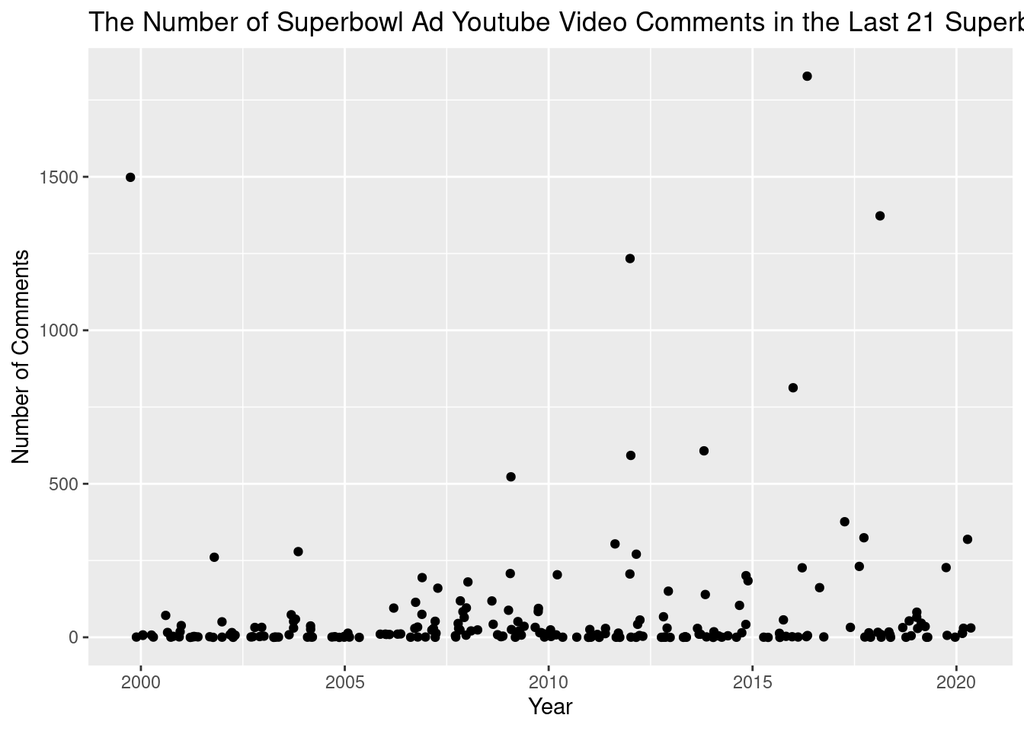

```r
youtube %>%
  filter(comment_count < 2500) %>%
  ggplot(aes(x = year, y = comment_count)) +
  geom_jitter() +
  labs(x = "Year",
       y = "Number of Comments",
       title = "The Number of Superbowl Ad Youtube Video Comments in the Last 21 Superbowls")
```

From this figure, we can see that most videos receive less than 500 comments, but there are a few ads in the last 10 years that have received up to 2000 comments. We will explore these ads and analyze their popularity and ad category to explain this trend.

Below, we show one of these visualizations, the relationship between the number of comments and the number of dislikes on ads in the last 21 Superbowls:

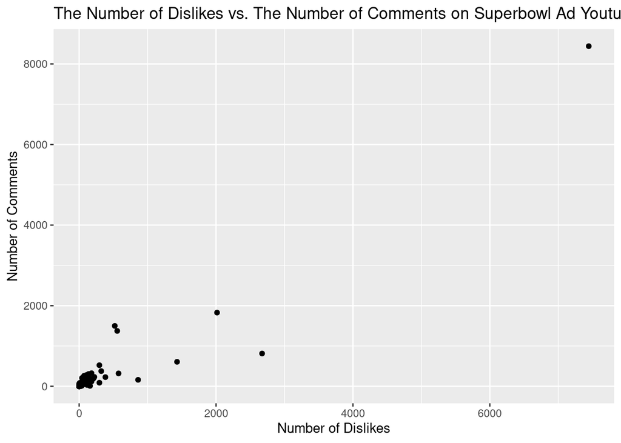

```r
youtube %>%
  filter(dislike_count < 10000) %>%
  ggplot(aes(x = dislike_count, y = comment_count)) +
  geom_jitter() +
  labs(x = "Number of Dislikes",
       y = "Number of Comments",
       title = "The Number of Dislikes vs. The Number of Comments on Superbowl Ad Youtube Videos")
```

From this figure, we see that there may be a positive relationship between the number of dislikes and the number of comments. We may use dislikes per view and likes per view in an attempt to scale these raw numbers.

We also plan to explore this relationship by ad category and by brand. This last figure shows the relationship between the number of comments and the number of dislikes on ads in the last 21 Superbowls by brand:

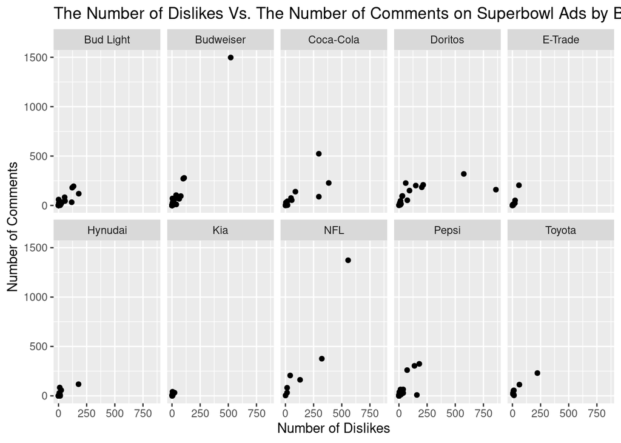

```r
youtube %>%
  filter(dislike_count < 1000) %>%
  ggplot(aes(x = dislike_count, y = comment_count)) +
  geom_jitter() +
  facet_wrap(~brand, ncol = 5) +
  labs(x = "Number of Dislikes",
       y = "Number of Comments",
       title = "The Number of Dislikes Vs. The Number of Comments on Superbowl Ads by Brand")
```

From this figure, we see that brands like Budweiser and the NFL receive more comments on ads with more dislikes. We wonder if this has to do with the ad category that these brands are airing during the Superbowl, and if these ads tend to be more problematic.

We then computed preliminary summary statistics to explore the Youtube video likes across the 10 brands:

```r
youtube %>%
  group_by(brand) %>%
  summarise(mean_likes = mean(like_count, na.rm = TRUE),
            median_likes = median(like_count, na.rm = TRUE),
            sd_likes = sd(like_count, na.rm = TRUE)) %>%
  arrange()
```

```
## # A tibble: 10 × 4
##    brand     mean_likes median_likes sd_likes
##    <chr>          <dbl>        <dbl>    <dbl>
##  1 Bud Light      1864.         62.5   12648.
##  2 Budweiser      2399.        138      8788.
##  3 Coca-Cola      8012.        226     23770.
##  4 Doritos       14180.        988     57092.
##  5 E-Trade         219.         74       375.
##  6 Hynudai         191.         21       344.
##  7 Kia             177.        123       167.
##  8 NFL           24918.       2215     57064.
##  9 Pepsi           616.        128.     1302.
## 10 Toyota          532.        244.      547.
```

Here, we can see that brands like Doritos and the NFL have the highest mean and median number of likes. We are hoping to explain this by the ad category and possibly the Youtube channel of these ads.

Then, we computed summary statistics to explore the number of ads that fall into a given category per brand:

```r
youtube %>%
  group_by(brand) %>%
  summarise(count_funny = sum(funny, na.rm = TRUE),
            count_show_product_quickly = sum(show_product_quickly, na.rm = TRUE),
            count_patriotic = sum(patriotic, na.rm = TRUE),
            count_celebrity = sum(celebrity, na.rm = TRUE),
            count_danger = sum(danger, na.rm = TRUE),
            count_animals = sum(animals, na.rm = TRUE),
            count_use_sex = sum(use_sex, na.rm = TRUE)) %>%
  arrange()
```

```
## # A tibble: 10 × 8
##    brand     count_funny count_show_product_qui… count_patriotic count_celebrity
##    <chr>           <int>                   <int>           <int>           <int>
##  1 Bud Light          60                      52               3              17
##  2 Budweiser          21                      27              16               5
##  3 Coca-Cola           8                      15               5               6
##  4 Doritos            24                      22               1               4
##  5 E-Trade            12                       7               2               0
##  6 Hynudai            12                      12               3               6
##  7 Kia                 8                       4               2               7
##  8 NFL                 2                       6               4               8
##  9 Pepsi              18                      15               3              16
## 10 Toyota              6                       9               2               2
## # … with 3 more variables: count_danger <int>, count_animals <int>,
## #   count_use_sex <int>
```

From this, we can see that Budweiser airs the most patriotic ads, while Bud Light airs the most funny ads. We will see if these ad categories make these brand ads more or less popular. We may make a pie chart using dips (a Superbowl reference of course!) to reflect the breakdown of ad types for each brand. Further, we’re hoping to use a faceted bar plot to view the popularity of various ad categories by brand to compare the effectiveness of different ad categories across brands.

[interactive chart not shown]

[interactive chart not shown]

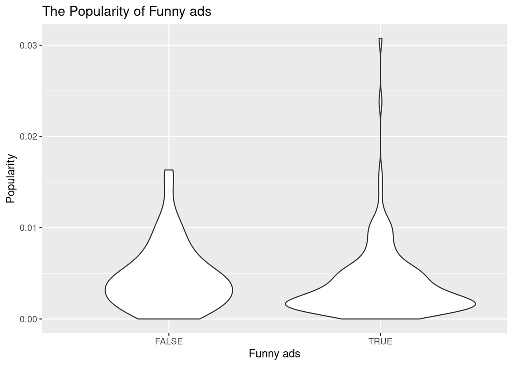

```r
youtube %>%
  mutate(likes_per_view = youtube$like_count/youtube$view_count)%>%
  ggplot(aes(x = funny,
             y = likes_per_view))+
    geom_violin()+
    labs(x = "Funny ads",
     y = "Popularity",
     title = "The Popularity of Funny ads")
```

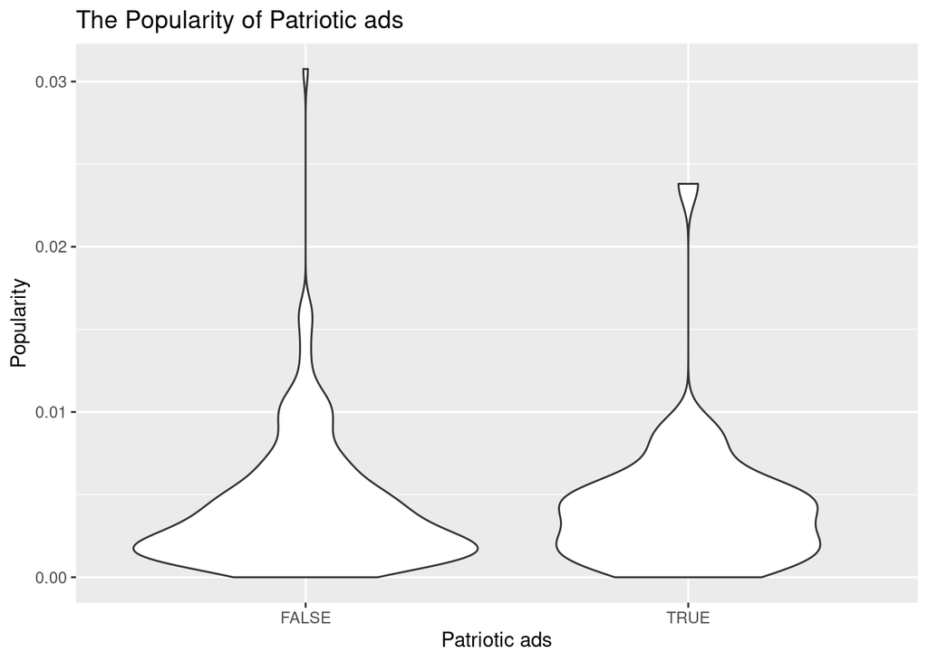

```r
youtube %>%
  mutate(likes_per_view = youtube$like_count/youtube$view_count)%>%
  ggplot(aes(x = patriotic,
             y = likes_per_view))+
    geom_violin()+
    labs(x = "Patriotic ads",
     y = "Popularity",
     title = "The Popularity of Patriotic ads")
```

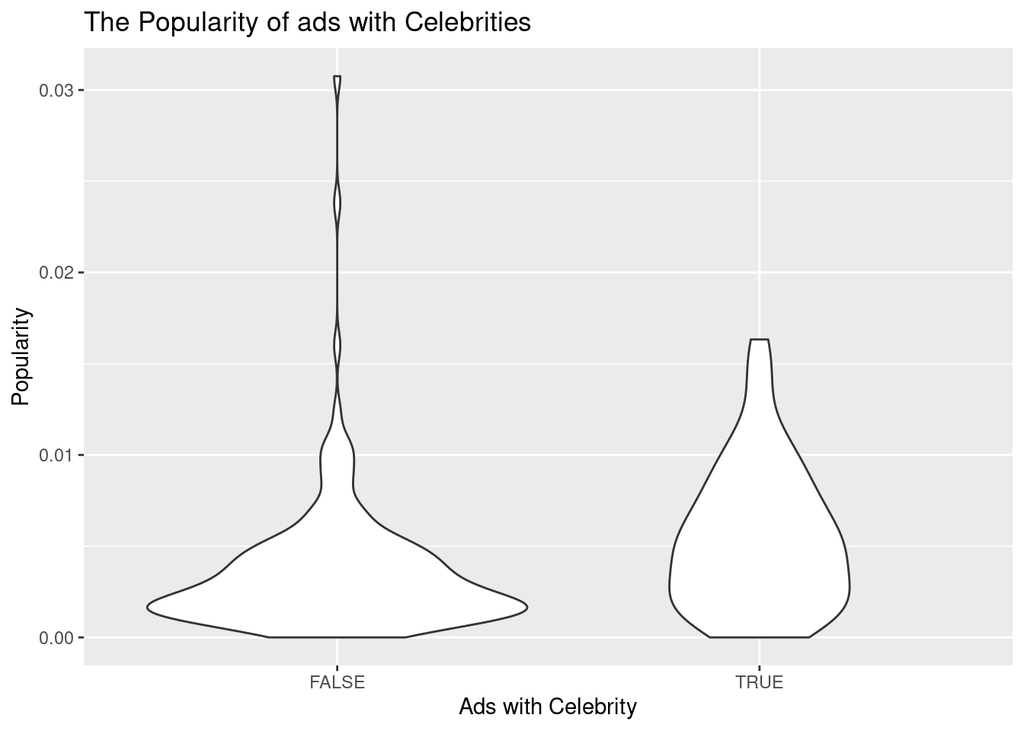

```r
youtube %>%
  mutate(likes_per_view = youtube$like_count/youtube$view_count)%>%
  ggplot(aes(x = celebrity,
             y = likes_per_view))+
    geom_violin()+
    labs(x = "Ads with Celebrity",
          y = "Popularity",
     title = "The Popularity of ads with Celebrities")
```

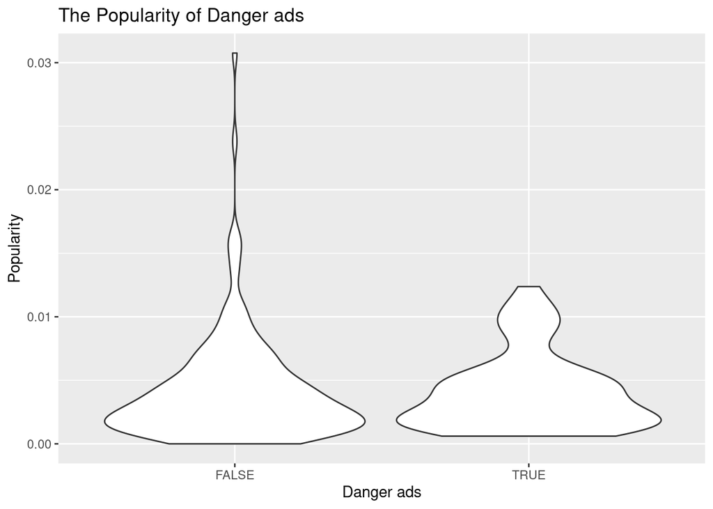

```r
youtube %>%
  mutate(likes_per_view = youtube$like_count/youtube$view_count)%>%
  ggplot(aes(x = danger,
             y = likes_per_view))+
    geom_violin()+
    labs(x = "Danger ads",
     y = "Popularity",
     title = "The Popularity of Danger ads")
```

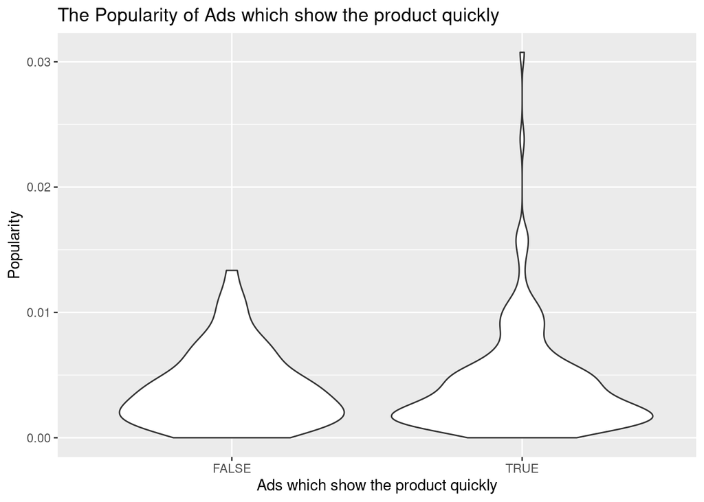

```r
youtube %>%
  mutate(likes_per_view = youtube$like_count/youtube$view_count)%>%
  ggplot(aes(x = show_product_quickly,
             y = likes_per_view))+
    geom_violin()+
    labs(x = "Ads which show the product quickly",
     y = "Popularity",
     title = "The Popularity of Ads which show the product quickly")
```

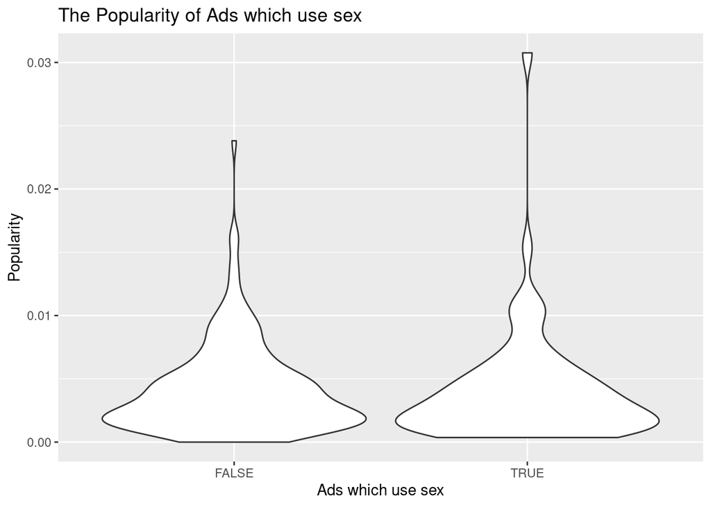

```r
youtube %>%
  mutate(likes_per_view = youtube$like_count/youtube$view_count)%>%
  ggplot(aes(x = use_sex,
             y = likes_per_view))+
    geom_violin()+
    labs(x = "Ads which use sex",
     y = "Popularity",
     title = "The Popularity of Ads which use sex")
```

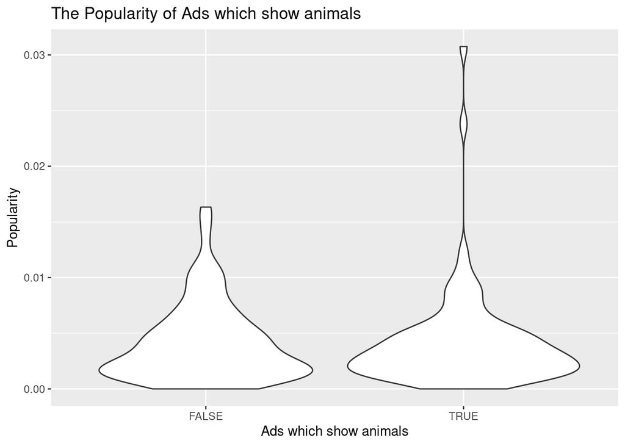

```r
youtube %>%
  mutate(likes_per_view = youtube$like_count/youtube$view_count)%>%
  ggplot(aes(x = animals,
             y = likes_per_view))+
    geom_violin()+
    labs(x = "Ads which show animals",
     y = "Popularity",
     title = "The Popularity of Ads which show animals")
```

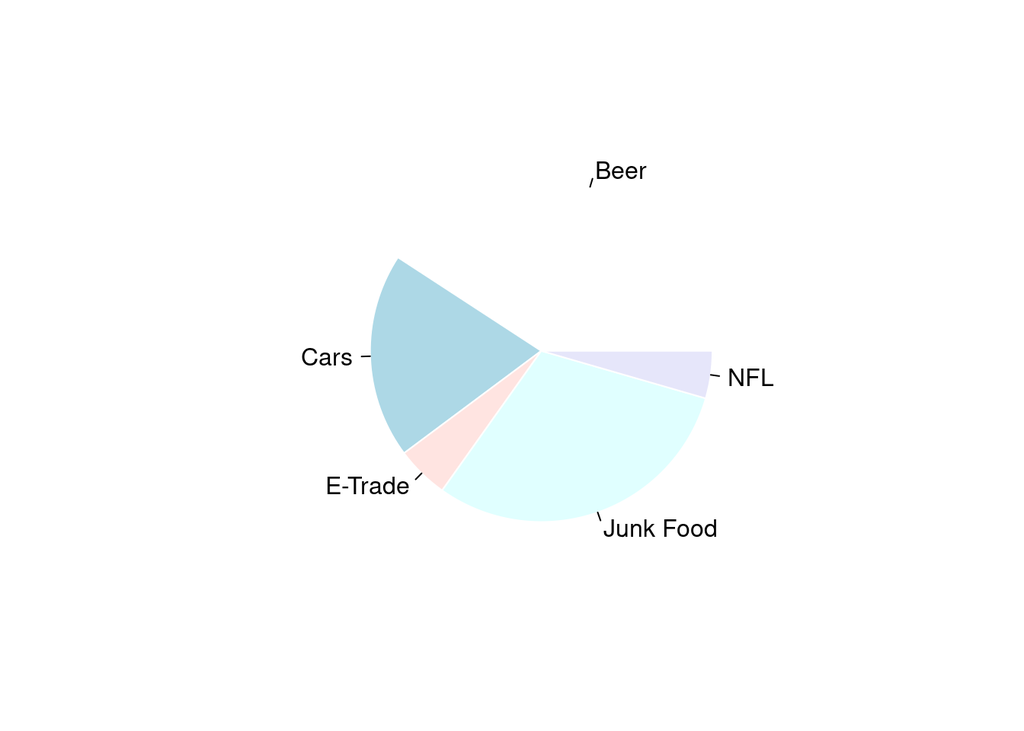

```r
ad_brand <- youtube %>%
            group_by(brand_type) %>%
            summarise(ad_count = n()) %>%
            mutate(prop_ad = ad_count/sum(ad_count))

pie(ad_brand$prop_ad, border="white", labels = c("Beer","Cars","E-Trade","Junk Food","NFL"))
```

The statistical methods that will be useful in answering our questions are:

- Average popularity of a given ad category across years of Superbowls
- Proportion of ads that have certain criteria per brand.
- Mean number of views for every year.
- Mean number of comments for data that filters for top five most popular and top 5 unpopular ads
- Correlation between number of comments and ad popularity
- Correlation between channel type and ad popularity

The results from these specific statistical methods that are needed to support our hypothesized answers are:

- Increasing average in popularity of a given ad category Brands will show a trend to market certain themes.
- Views will increase as time goes on
- There will be a positive or negative correlation between number of comments and ad popularity that will reflect that ads that are either well-liked or hated by the public receive the highest number of comments.